# Lab Assignment Six: Convolutional Network Architectures

## *Yiwen Xu, Kehan Zhang, Shuang Liang, Christopher Deng Jr*

# 1 Data Preparation

For this lab, we pick this dataset that is a collection of images of human faces that was created two years ago. Some of them are wearing a mask, some of them are not. Images with face mask are scrapped rom google search and images without a face mask are gathered from the CelebFace dataset(https://www.kaggle.com/jessicali9530).

This dataset is gathered to create a mask detection algorithm. The algorithm can detect if the person is wearing a mask or not. It can be widely used in public places and in private areas. Government can be interested in these results as it can be used to track down people who are not wearing mask in case there’s a disease outbreak. People who are not wearing a mask are more prone to get the disease and to spread the disease. The government can use this data to better warn people and stop the disease from spreading. Using the data, the government can have a big advantage in their effort in predicting how the disease will spread and can save a lot of time and money. Private labs and factories can also be interested in these results as well. They can used this to make sure workers are wearing their mask so they can prevent workers from breathing in toxic materials and stop accidents from happening. Hospital is another party that can be interested in the result. Hospitals can use it to make sure that the doctors and nurses are wearing the mask as required. So, both the patients and employees can be safe.

## 1.1 Load the dataset

```python
import os
import pandas as pd
import numpy as np
import matplotlib.pyplot as plt
import seaborn as sn
import cv2
from random import randint
import tensorflow as tf
from PIL import Image
import warnings
warnings.filterwarnings("ignore")

import os
os.environ['KMP_DUPLICATE_LIB_OK']='True'
```

```
2022-12-03 21:32:08.410239: I tensorflow/core/platform/cpu_feature_guard.cc:193] This TensorFlow binary is optimized with oneAPI Deep Neural Network Library (oneDNN) to use the following CPU instructions in performance-critical operations:  AVX2 AVX512F AVX512_VNNI FMA
To enable them in other operations, rebuild TensorFlow with the appropriate compiler flags.
```

```python
cv2.__version__
```

```
'4.6.0'
```

```python
tf.__version__
```

```
'2.10.0'
```

```python
%%time
# ouput img properties

# https://blog.csdn.net/weixin_44015965/article/details/109547129
def funOutputImgProperties(img):
    print("properties:shape:{},size:{},dtype:{}".format(img.shape,img.size,img.dtype))

dim = (50,50) # set image size as 100*100
dataset_data = np.empty([0,(dim[0]*dim[1])])# Array to save data
dataset_target = np.empty([0,1])
max_quantity_per_class = 5000 # Make it not too big
dataset_rgb = []

# Read Dataset
a = os.walk(r'Face_Mask_Dataset/Train')
for root,dirs,files in os.walk(r'Face_Mask_Dataset/Train'):
    i = 0
    for name in files:
        if ".DS_Store" not in name:# It's a Problem that macos's unzip file have,just ignore it.
            img_path = os.path.join(root, name)
            I = cv2.imread(img_path,cv2.IMREAD_GRAYSCALE) # to grayscale
            I2 = cv2.imread(img_path, cv2.IMREAD_COLOR)[:, :, ::-1]

            image_arr = cv2.resize(I,dim) # resize to dim we set
            image_arr2 = cv2.resize(I2,dim) # resize to dim we set

            image_arr = image_arr.reshape(1,image_arr.size) # make it array
            dataset_rgb.append(image_arr2) # save for exceptional work

            label = (str(os.path.basename(os.path.dirname(img_path))))
            if label == 'WithMask':
                label = int(1)
            else:
                label = int(0)

            dataset_target = np.row_stack((dataset_target,label))
            dataset_data = np.row_stack((dataset_data,image_arr))
            i = i+1
            if(i==max_quantity_per_class):
                i = 0
                break

dataset_rgb = np.array(dataset_rgb)
dataset_data
```

```
CPU times: user 5min 50s, sys: 6min 3s, total: 11min 53s
Wall time: 12min 18s
```

```
array([[ 20.,  20.,  22., ...,  26.,  23.,  29.],
       [127., 127., 124., ..., 141., 114., 107.],
       [ 47.,  41.,  34., ...,  20.,  22.,  20.],
       ...,
       [  0.,   0.,   0., ...,  47., 147., 153.],
       [  0.,   1.,  12., ...,  83.,  89.,  97.],
       [ 42.,  52.,  60., ...,  21.,  21.,  21.]])
```

```python
X = dataset_data
Y = dataset_target

n_samples, n_features = X.shape
n_classes = len(Y)
h = dim[0]
w = dim[1]
print(np.sum(~np.isfinite(X)))
print("n_samples: {}".format(n_samples))
print("n_features: {}".format(n_features))
print("n_classes: {}".format(n_classes))

print("Original Image Sizes {} by {}".format(h,w))
print (h*w) # the size of the images are the size of the feature vectors
```

```
0
n_samples: 10000
n_features: 2500
n_classes: 10000
Original Image Sizes 50 by 50
2500
```

[figure not shown]

```python
# a helper plotting function
import matplotlib
import matplotlib.pyplot as plt
import random
# modified from original to plot random sample
def plot_gallery(images, titles, h, w, n_row=3, n_col=6):
    """Helper function to plot a gallery of portraits"""
    plt.figure(figsize=(2.3 * n_col, 2.3 * n_row))
    plt.subplots_adjust(bottom=0, left=.01, right=.99, top=.90, hspace=.35)
    plot_index=random.sample(range(0,len(X)),n_row * n_col)
    for i in range(n_row * n_col):
        plt.subplot(n_row, n_col, i + 1)
        plt.imshow(images[plot_index[i]].reshape((h, w)), cmap=plt.cm.gray)
        plt.title(titles[plot_index[i]], size=12)
        plt.xticks(())
        plt.yticks(())

plot_gallery(dataset_data, dataset_target, h, w)
```

## 1.2 The Metric that are going to use to evaluate our algorithm’s performance.

Here we choose to use the Precision as the metric to evaluate the peroformance. Here is the reason:

In this project we want to classify whether people in the picture is wearing or not the mask. For any potential third party user/organization, it is obviously a huge problem if the model says they wear the mask but actually they are not. Even tiny mistake could couse huge problem, especially in some lab, hospital and chemical plant. It would lead to some serious safety problem. That is, we want the metric focus on the lowest false postives(FP) rather then other. The metric percision, which is caculate by $(TP) /(TP+FP)$.

## 1.3 Dividing the Data

For diving our data, we choose to do the 80/20 split. We choose to do this because we have enough data entries over 10K. We also believe that we don't need to do cross validation also because we have enough data entries so over fitting shouldn't occur.

```python
from sklearn.model_selection import train_test_split

X_train,X_test,y_train,y_test=train_test_split(X, Y, test_size=0.2, random_state=1, shuffle = True)

X_train = X_train/255.0-0.5
X_test = X_test/255.0-0.5
NUM_CLASSES = 1
img_wh = dim[0]

X_train = np.expand_dims(X_train.reshape((-1,img_wh,img_wh)), axis=3)
X_test = np.expand_dims(X_test.reshape((-1,img_wh,img_wh)), axis=3)

# y_train_ohe = keras.utils.to_categorical(y_train, NUM_CLASSES)
# y_test_ohe = keras.utils.to_categorical(y_test, NUM_CLASSES)

print('train:', y_train.shape[0]/Y.shape[0])
print('test:', y_test.shape[0]/Y.shape[0])
```

```
train: 0.8
test: 0.2
```

```
(8000, 50, 50, 1)
```

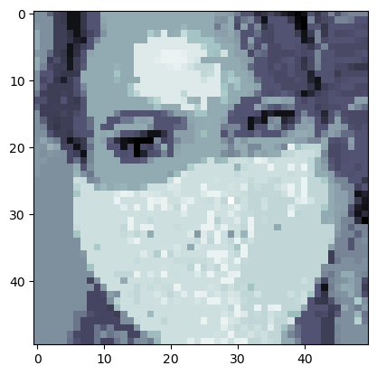

```python
print(X_train.shape)
plt.subplot(1,1,1)
plt.imshow(X_train[1].squeeze(),cmap='bone')
plt.show()
```

# 2 Modeling

## 2.1 Data Expansion

Here, we use `ImageDataGenerator` from Keras to augment the training dataset.

```python
import tensorflow.keras as keras
from tensorflow.keras.preprocessing.image import ImageDataGenerator

keras.__version__
```

```
'2.10.0'
```

```python
# initialize image data generator for later use

datagen = ImageDataGenerator(
    featurewise_center=False,
    samplewise_center=False,
    featurewise_std_normalization=False,
    samplewise_std_normalization=False,
    zca_whitening=False,
    rotation_range=45, # used, Int. Degree range for random rotations.
    width_shift_range=0.1, # used, Float (fraction of total width). Range for random horizontal shifts.
    height_shift_range=0.1, # used,  Float (fraction of total height). Range for random vertical shifts.
    shear_range=0., # Float. Shear Intensity (Shear angle in counter-clockwise direction as radians)
    zoom_range=0.2,
    channel_shift_range=0.,
    fill_mode='nearest',
    cval=0.,
    horizontal_flip=True,
    vertical_flip=False,
    rescale=None)

datagen.fit(X_train)

# Add augmented data to training data set
X_new, y_new = datagen.flow(X_train, y_train, batch_size=int(len(X_train)/5)).next()
X_train = np.concatenate((X_train, X_new))
y_train = np.concatenate((y_train, y_new))

print(X_train.shape)
print(y_train.shape)
```

```
(9600, 50, 50, 1)
(9600, 1)
```

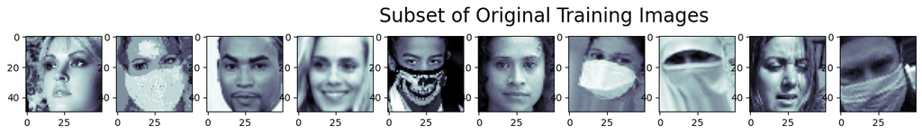

```python
# Display original training images
X_train_subset1 = np.squeeze(X_train[:10])
X_train_subset2 = X_train[:10]

plt.set_cmap('bone')
fig = plt.figure(figsize=(20, 2))
for i in range(0, len(X_train_subset1)):
    ax = fig.add_subplot(1, 12, i + 1)
    ax.imshow(X_train_subset1[i])
fig.suptitle('Subset of Original Training Images', fontsize=20)
plt.show()
```

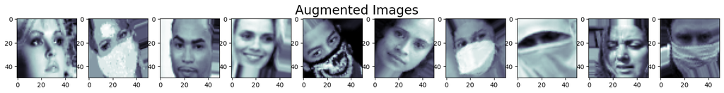

```python
# Display augmented images
fig = plt.figure(figsize=(20, 2))

# The .flow function can return batch data in an infinite loop for a given numpy dataset
for X_batch in datagen.flow(X_train_subset2, batch_size=12, shuffle=False):
    for i in range(0, 10):
        ax = fig.add_subplot(1, 10, i + 1)
        ax.imshow(np.squeeze(X_batch[i]))
    fig.suptitle('Augmented Images', fontsize=20)
    plt.show()
    break;
```

Through comparing the images above, we decided to expand our training dataset with rotation, zoom and shift techniques. This is because we have reason to consider that there may be many different cameras capturing the instantaneous situation. We also used only the horizontal flip technique to further distinguish the expanded data from the original data, since it is rarely possible to apply this model to upside-down images.

## 2.2 Convolutional Neural Networks with Visualization

```python
import tensorflow.keras as keras
from tensorflow.keras.models import Sequential
from tensorflow.keras.layers import Reshape, Input
from tensorflow.keras.layers import Dense, Dropout, Activation, Flatten
from tensorflow.keras.layers import Conv2D, MaxPooling2D
from tensorflow.keras.preprocessing.image import ImageDataGenerator
from tensorflow.keras.callbacks import EarlyStopping
from tensorflow.keras.regularizers import l2
from tensorflow.keras.layers import average
from tensorflow.keras.models import  Model

keras.__version__
```

```
'2.10.0'
```

```python
from sklearn import metrics as mt
from matplotlib import pyplot as plt
from skimage.io import imshow
import seaborn as sns
%matplotlib inline

labels = ['WithMask', 'WithoutMask']
```

```python
# helper function that plots training recall history, validation recall history,
# training BCE loss history, and validation BCE loss history

from matplotlib import pyplot as plt

%matplotlib inline

def plot_history(model_history):
    plt.figure(figsize=(10,4))
    plt.subplot(2,2,1)
    plt.plot(list(model_history.history.values())[1])

    plt.ylabel('Precision')
    plt.title('Training')
    plt.subplot(2,2,2)
    plt.plot(list(model_history.history.values())[3])
    plt.title('Validation')

    plt.subplot(2,2,3)
    plt.plot(model_history.history['loss'])
    plt.ylabel('Training Loss')
    plt.xlabel('epochs')

    plt.subplot(2,2,4)
    plt.plot(model_history.history['val_loss'])
    plt.xlabel('epochs')

    plt.show()

def show_confusion_matrix(cnn, X_test, y_test, labels='auto', title_text='CNN:'):
    plt.figure(figsize=(15,5))
    yhat = np.round(cnn.predict(X_test))
    acc = mt.precision_score(y_test,yhat)
    plt.subplot(1,2,1)
    cm = mt.confusion_matrix(y_test,yhat)
    cm = cm/np.sum(cm,axis=1)[:,np.newaxis]
    sns.heatmap(cm, annot=True, fmt='.2f', xticklabels=labels,yticklabels=labels)
    plt.title(title_text+'{:.4f}'.format(acc))
```

### 2.2.1 AlexNet Architecture(Filters: 16, 32)

```python
%%time

cnn_alexnet_16 = Sequential()

# let's start with an AlexNet style convolutional phase
cnn_alexnet_16.add(Conv2D(filters=16,
                input_shape = (img_wh,img_wh,1),
                kernel_size=(3,3),
                padding='same',
                activation='relu', data_format="channels_last")) # more compact syntax

# no max pool before next conv layer!!
cnn_alexnet_16.add(Conv2D(filters=32,
                kernel_size=(3,3),
                padding='same',
                activation='relu')) # more compact syntax
cnn_alexnet_16.add(MaxPooling2D(pool_size=(2, 2), data_format="channels_last"))

# add one layer on flattened output
cnn_alexnet_16.add(Dropout(0.25)) # add some dropout for regularization after conv layers
cnn_alexnet_16.add(Flatten())
cnn_alexnet_16.add(Dense(128, activation='relu'))
cnn_alexnet_16.add(Dropout(0.5)) # add some dropout for regularization, again!
cnn_alexnet_16.add(Dense(1, activation='sigmoid'))

cnn_alexnet_16.summary()

# Let's train the model
cnn_alexnet_16.compile(loss='binary_crossentropy', # 'categorical_crossentropy' 'mean_squared_error'
              optimizer='adam', # 'adadelta' 'rmsprop'
              metrics=keras.metrics.Precision())

# the flow method yields batches of images indefinitely, with the given transformations
cnn_alexnet_16_history = cnn_alexnet_16.fit(X_train, y_train,
                   epochs=20, verbose=1, validation_data=(X_test,y_test)
                  )
```

```
Model: "sequential_2"
_________________________________________________________________
 Layer (type)                Output Shape              Param #
=================================================================
 conv2d_4 (Conv2D)           (None, 50, 50, 16)        160

 conv2d_5 (Conv2D)           (None, 50, 50, 32)        4640

 max_pooling2d_2 (MaxPooling  (None, 25, 25, 32)       0
 2D)

 dropout_4 (Dropout)         (None, 25, 25, 32)        0

 flatten_2 (Flatten)         (None, 20000)             0

 dense_4 (Dense)             (None, 128)               2560128

 dropout_5 (Dropout)         (None, 128)               0

 dense_5 (Dense)             (None, 1)                 129

=================================================================
Total params: 2,565,057
Trainable params: 2,565,057
Non-trainable params: 0
_________________________________________________________________
CPU times: user 18min 28s, sys: 11min 16s, total: 29min 45s
Wall time: 6min 16s
```

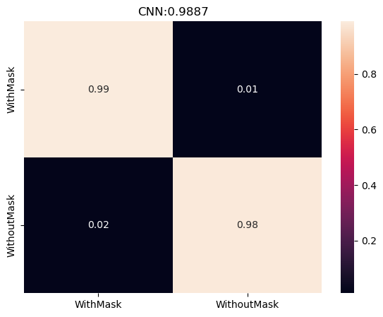

```python
show_confusion_matrix(cnn_alexnet_16,X_test,y_test,labels)
```

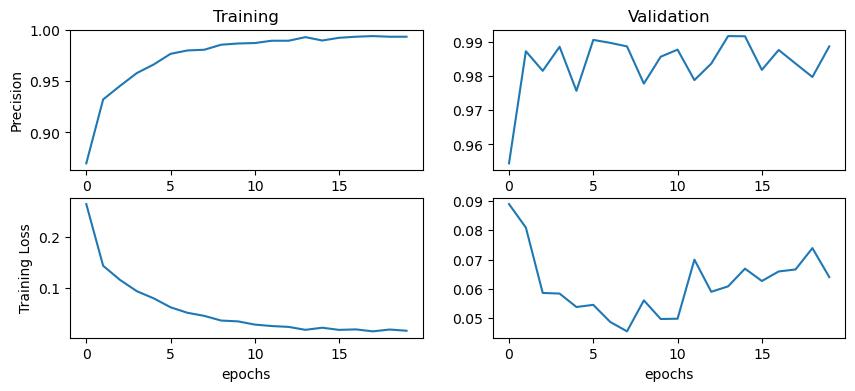

```python
plot_history(cnn_alexnet_16_history)
```

### 2.2.2 AlexNet Architecture(Filters: 32, 64)

```python
%%time

cnn_alexnet_32 = Sequential()

# let's start with an AlexNet style convolutional phase
cnn_alexnet_32.add(Conv2D(filters=32,
                input_shape = (img_wh,img_wh,1),
                kernel_size=(3,3),
                padding='same',
                activation='relu', data_format="channels_last")) # more compact syntax

# no max pool before next conv layer!!
cnn_alexnet_32.add(Conv2D(filters=64,
                kernel_size=(3,3),
                padding='same',
                activation='relu')) # more compact syntax
cnn_alexnet_32.add(MaxPooling2D(pool_size=(2, 2), data_format="channels_last"))

# add one layer on flattened output
cnn_alexnet_32.add(Dropout(0.25)) # add some dropout for regularization after conv layers
cnn_alexnet_32.add(Flatten())
cnn_alexnet_32.add(Dense(128, activation='relu'))
cnn_alexnet_32.add(Dropout(0.5)) # add some dropout for regularization, again!
cnn_alexnet_32.add(Dense(1, activation='sigmoid'))

cnn_alexnet_32.summary()

# Let's train the model
cnn_alexnet_32.compile(loss='binary_crossentropy', # 'categorical_crossentropy' 'mean_squared_error'
              optimizer='adam', # 'adadelta' 'rmsprop'
              metrics=keras.metrics.Precision())

# the flow method yields batches of images indefinitely, with the given transformations
cnn_alexnet_32_history = cnn_alexnet_32.fit(X_train, y_train,
                   epochs=20, verbose=1, validation_data=(X_test,y_test)
                  )
```

```
Model: "sequential_3"
_________________________________________________________________
 Layer (type)                Output Shape              Param #
=================================================================
 conv2d_6 (Conv2D)           (None, 50, 50, 32)        320

 conv2d_7 (Conv2D)           (None, 50, 50, 64)        18496

 max_pooling2d_3 (MaxPooling  (None, 25, 25, 64)       0
 2D)

 dropout_6 (Dropout)         (None, 25, 25, 64)        0

 flatten_3 (Flatten)         (None, 40000)             0

 dense_6 (Dense)             (None, 128)               5120128

 dropout_7 (Dropout)         (None, 128)               0

 dense_7 (Dense)             (None, 1)                 129

=================================================================
Total params: 5,139,073
Trainable params: 5,139,073
Non-trainable params: 0
_________________________________________________________________
CPU times: user 41min 7s, sys: 14min 11s, total: 55min 18s
Wall time: 10min 42s
```

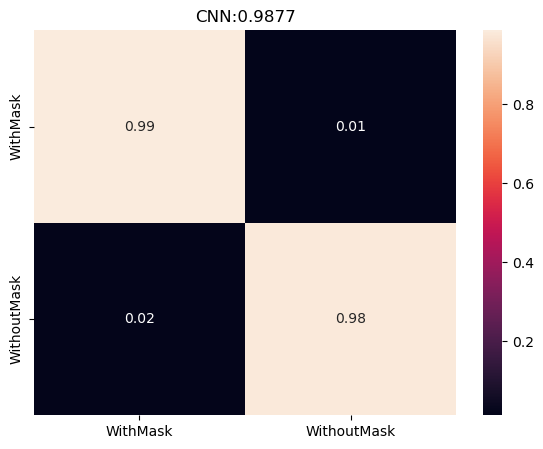

```python
show_confusion_matrix(cnn_alexnet_32,X_test,y_test,labels)
```

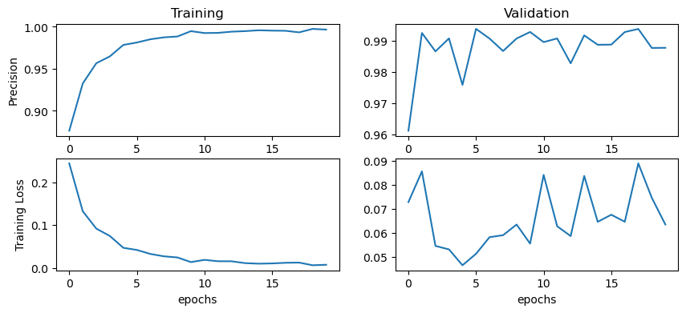

```python
plot_history(cnn_alexnet_32_history)
```

```python
%%time

from tensorflow.keras.layers import Add, Input
from tensorflow.keras.layers import average, concatenate
from tensorflow.keras.models import Model

l2_lambda = 0.000001

input_holder = Input(shape=(img_wh, img_wh, 1))

# start with a conv layer
x = Conv2D(filters=16,
               input_shape = (img_wh,img_wh,1),
               kernel_size=(3,3),
               kernel_initializer='he_uniform',
               kernel_regularizer=l2(l2_lambda),
               padding='same',
               activation='relu',
               data_format="channels_last")(input_holder)

x = MaxPooling2D(pool_size=(2, 2), data_format="channels_last")(x)

x = Conv2D(filters=16,
               kernel_size=(3,3),
               kernel_initializer='he_uniform',
               kernel_regularizer=l2(l2_lambda),
               padding='same',
               activation='relu',
               data_format="channels_last")(x)

x_split = MaxPooling2D(pool_size=(2, 2), data_format="channels_last")(x)

x = Conv2D(filters=32,
               kernel_size=(1,1),
               kernel_initializer='he_uniform',
               kernel_regularizer=l2(l2_lambda),
               padding='same',
               activation='relu',
               data_format="channels_last")(x_split)

x = Conv2D(filters=32,
               kernel_size=(3,3),
               kernel_initializer='he_uniform',
               kernel_regularizer=l2(l2_lambda),
               padding='same',
               activation='relu',
               data_format="channels_last")(x)

x = Conv2D(filters=16,
               kernel_size=(1,1),
               kernel_initializer='he_uniform',
               kernel_regularizer=l2(l2_lambda),
               padding='same',
               activation='relu',
               data_format="channels_last")(x)

# now add back in the split layer, x_split (residual added in)
x = Add()([x, x_split])
x = Activation("relu")(x)

x = MaxPooling2D(pool_size=(2, 2), data_format="channels_last")(x)

x = Flatten()(x)
x = Dropout(0.25)(x)
x = Dense(128)(x)
x = Activation("relu")(x)
x = Dropout(0.5)(x)
x = Dense(1)(x)
x = Activation('sigmoid')(x)

cnn_resnet_16 = Model(inputs=input_holder,outputs=x)

cnn_resnet_16.summary()

# Let's train the model
cnn_resnet_16.compile(loss='binary_crossentropy', # 'categorical_crossentropy' 'mean_squared_error'
              optimizer='adam', # 'adadelta' 'rmsprop'
              metrics=keras.metrics.Precision())

# the flow method yields batches of images indefinitely, with the given transformations
cnn_resnet_16_history = cnn_resnet_16.fit(X_train, y_train,
                   epochs=20, verbose=1, validation_data=(X_test,y_test)
                  )
```

```
Model: "model"
__________________________________________________________________________________________________
 Layer (type)                   Output Shape         Param #     Connected to
==================================================================================================
 input_1 (InputLayer)           [(None, 50, 50, 1)]  0           []

 conv2d_8 (Conv2D)              (None, 50, 50, 16)   160         ['input_1[0][0]']

 max_pooling2d_4 (MaxPooling2D)  (None, 25, 25, 16)  0           ['conv2d_8[0][0]']

 conv2d_9 (Conv2D)              (None, 25, 25, 16)   2320        ['max_pooling2d_4[0][0]']

 max_pooling2d_5 (MaxPooling2D)  (None, 12, 12, 16)  0           ['conv2d_9[0][0]']

 conv2d_10 (Conv2D)             (None, 12, 12, 32)   544         ['max_pooling2d_5[0][0]']

 conv2d_11 (Conv2D)             (None, 12, 12, 32)   9248        ['conv2d_10[0][0]']

 conv2d_12 (Conv2D)             (None, 12, 12, 16)   528         ['conv2d_11[0][0]']

 add (Add)                      (None, 12, 12, 16)   0           ['conv2d_12[0][0]',
                                                                  'max_pooling2d_5[0][0]']

 activation (Activation)        (None, 12, 12, 16)   0           ['add[0][0]']

 max_pooling2d_6 (MaxPooling2D)  (None, 6, 6, 16)    0           ['activation[0][0]']

 flatten_4 (Flatten)            (None, 576)          0           ['max_pooling2d_6[0][0]']

 dropout_8 (Dropout)            (None, 576)          0           ['flatten_4[0][0]']

 dense_8 (Dense)                (None, 128)          73856       ['dropout_8[0][0]']

 activation_1 (Activation)      (None, 128)          0           ['dense_8[0][0]']

 dropout_9 (Dropout)            (None, 128)          0           ['activation_1[0][0]']

 dense_9 (Dense)                (None, 1)            129         ['dropout_9[0][0]']

 activation_2 (Activation)      (None, 1)            0           ['dense_9[0][0]']

==================================================================================================
Total params: 86,785
Trainable params: 86,785
Non-trainable params: 0
__________________________________________________________________________________________________
CPU times: user 7min 47s, sys: 6min 14s, total: 14min 1s
Wall time: 3min 18s
```

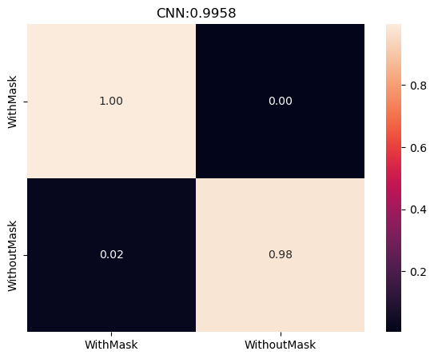

```python
show_confusion_matrix(cnn_resnet_16,X_test,y_test,labels)
```

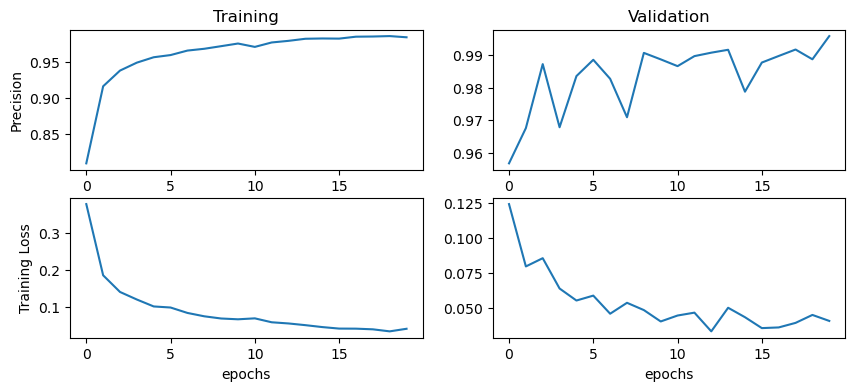

```python
plot_history(cnn_resnet_16_history)
```

```python
%%time

input_holder = Input(shape=(img_wh, img_wh, 1))

# start with a conv layer
x = Conv2D(filters=32,
               input_shape = (img_wh,img_wh,1),
               kernel_size=(3,3),
               kernel_initializer='he_uniform',
               kernel_regularizer=l2(l2_lambda),
               padding='same',
               activation='relu',
               data_format="channels_last")(input_holder)

x = MaxPooling2D(pool_size=(2, 2), data_format="channels_last")(x)

x = Conv2D(filters=32,
               kernel_size=(3,3),
               kernel_initializer='he_uniform',
               kernel_regularizer=l2(l2_lambda),
               padding='same',
               activation='relu',
               data_format="channels_last")(x)

x_split = MaxPooling2D(pool_size=(2, 2), data_format="channels_last")(x)

x = Conv2D(filters=64,
               kernel_size=(1,1),
               kernel_initializer='he_uniform',
               kernel_regularizer=l2(l2_lambda),
               padding='same',
               activation='relu',
               data_format="channels_last")(x_split)

x = Conv2D(filters=64,
               kernel_size=(3,3),
               kernel_initializer='he_uniform',
               kernel_regularizer=l2(l2_lambda),
               padding='same',
               activation='relu',
               data_format="channels_last")(x)

x = Conv2D(filters=32,
               kernel_size=(1,1),
               kernel_initializer='he_uniform',
               kernel_regularizer=l2(l2_lambda),
               padding='same',
               activation='relu',
               data_format="channels_last")(x)

# now add back in the split layer, x_split (residual added in)
x = Add()([x, x_split])
x = Activation("relu")(x)

x = MaxPooling2D(pool_size=(2, 2), data_format="channels_last")(x)

x = Flatten()(x)
x = Dropout(0.25)(x)
x = Dense(128)(x)
x = Activation("relu")(x)
x = Dropout(0.5)(x)
x = Dense(1)(x)
x = Activation('sigmoid')(x)

cnn_resnet_32 = Model(inputs=input_holder,outputs=x)

cnn_resnet_32.summary()

# Let's train the model
cnn_resnet_32.compile(loss='binary_crossentropy', # 'categorical_crossentropy' 'mean_squared_error'
              optimizer='adam', # 'adadelta' 'rmsprop'
              metrics=keras.metrics.Precision())

# the flow method yields batches of images indefinitely, with the given transformations
cnn_resnet_32_history = cnn_resnet_32.fit(X_train, y_train,
                   epochs=20, verbose=1, validation_data=(X_test,y_test)
                  )
```

```
Model: "model_1"
__________________________________________________________________________________________________
 Layer (type)                   Output Shape         Param #     Connected to
==================================================================================================
 input_2 (InputLayer)           [(None, 50, 50, 1)]  0           []

 conv2d_13 (Conv2D)             (None, 50, 50, 32)   320         ['input_2[0][0]']

 max_pooling2d_7 (MaxPooling2D)  (None, 25, 25, 32)  0           ['conv2d_13[0][0]']

 conv2d_14 (Conv2D)             (None, 25, 25, 32)   9248        ['max_pooling2d_7[0][0]']

 max_pooling2d_8 (MaxPooling2D)  (None, 12, 12, 32)  0           ['conv2d_14[0][0]']

 conv2d_15 (Conv2D)             (None, 12, 12, 64)   2112        ['max_pooling2d_8[0][0]']

 conv2d_16 (Conv2D)             (None, 12, 12, 64)   36928       ['conv2d_15[0][0]']

 conv2d_17 (Conv2D)             (None, 12, 12, 32)   2080        ['conv2d_16[0][0]']

 add_1 (Add)                    (None, 12, 12, 32)   0           ['conv2d_17[0][0]',
                                                                  'max_pooling2d_8[0][0]']

 activation_3 (Activation)      (None, 12, 12, 32)   0           ['add_1[0][0]']

 max_pooling2d_9 (MaxPooling2D)  (None, 6, 6, 32)    0           ['activation_3[0][0]']

 flatten_5 (Flatten)            (None, 1152)         0           ['max_pooling2d_9[0][0]']

 dropout_10 (Dropout)           (None, 1152)         0           ['flatten_5[0][0]']

 dense_10 (Dense)               (None, 128)          147584      ['dropout_10[0][0]']

 activation_4 (Activation)      (None, 128)          0           ['dense_10[0][0]']

 dropout_11 (Dropout)           (None, 128)          0           ['activation_4[0][0]']

 dense_11 (Dense)               (None, 1)            129         ['dropout_11[0][0]']

 activation_5 (Activation)      (None, 1)            0           ['dense_11[0][0]']

==================================================================================================
Total params: 198,401
Trainable params: 198,401
Non-trainable params: 0
__________________________________________________________________________________________________
CPU times: user 14min 24s, sys: 12min 21s, total: 26min 46s
Wall time: 5min 47s
```

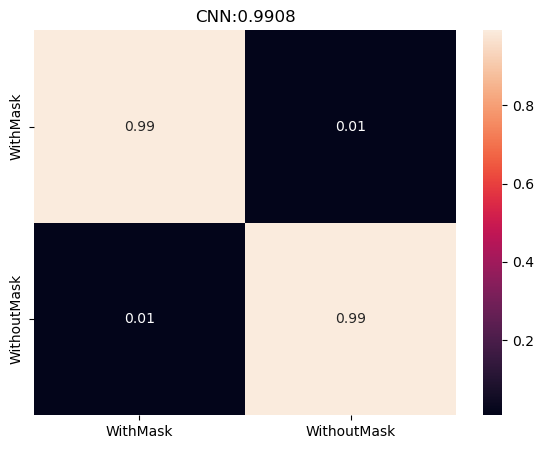

```python
show_confusion_matrix(cnn_resnet_32,X_test,y_test,labels)
```

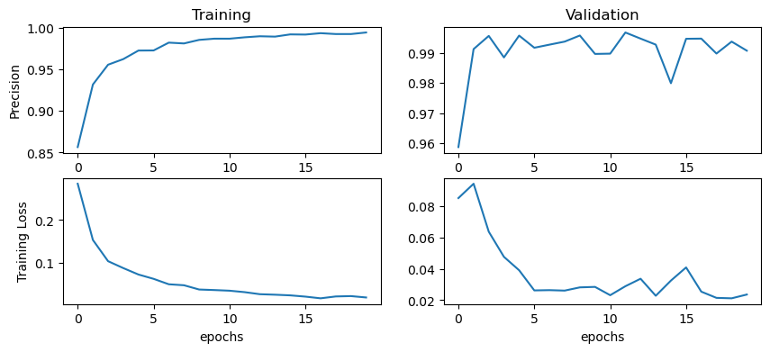

```python
plot_history(cnn_resnet_32_history)
```

## 2.3 Compare Performance of CNNs

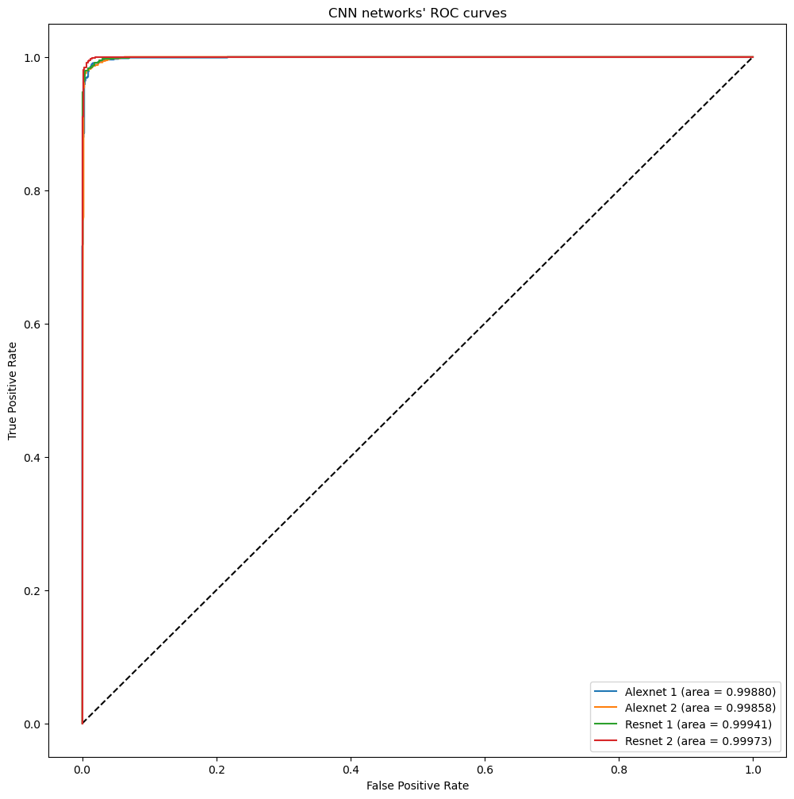

```python
from sklearn.metrics import roc_curve, roc_auc_score, average_precision_score, auc

y_pred_1 = cnn_alexnet_16.predict(X_test).ravel()
fpr_cnn1, tpr_cnn1, thresholds_cnn1 = roc_curve(y_test, y_pred_1)
precision_1 = auc(fpr_cnn1, tpr_cnn1)

y_pred_2 = cnn_alexnet_32.predict(X_test).ravel()
fpr_cnn2, tpr_cnn2, thresholds_cnn2 = roc_curve(y_test, y_pred_2)
precision_2 = auc(fpr_cnn2, tpr_cnn2)

y_pred_3 = cnn_resnet_16.predict(X_test).ravel()
fpr_cnn3, tpr_cnn3, thresholds_cnn3 = roc_curve(y_test, y_pred_3)
precision_3 = auc(fpr_cnn3, tpr_cnn3)

y_pred_4 = cnn_resnet_32.predict(X_test).ravel()
fpr_cnn4, tpr_cnn4, thresholds_cnn4 = roc_curve(y_test, y_pred_4)
precision_4 = auc(fpr_cnn4, tpr_cnn4)


plt.figure(figsize=(12,12))

#plot halfway line
plt.plot([0,1], [0,1], 'k--')

plt.plot(fpr_cnn1, tpr_cnn1, label='Alexnet 1 (area = {:.5f})'.format(precision_1))
plt.plot(fpr_cnn2, tpr_cnn2, label='Alexnet 2 (area = {:.5f})'.format(precision_2))
plt.plot(fpr_cnn3, tpr_cnn3, label='Resnet 1 (area = {:.5f})'.format(precision_3))
plt.plot(fpr_cnn4, tpr_cnn4, label='Resnet 2 (area = {:.5f})'.format(precision_4))

plt.xlabel('False Positive Rate')
plt.ylabel('True Positive Rate')
plt.title('CNN networks\' ROC curves')
plt.legend(loc='best')
plt.show()
```

```python
def create_contingency_McNemar(y_test, model1_pred, model2_pred):

    correct1_correct2 = 0  # model 1 predict correctly, model 2 also predict correctly
    correct1_wrong2 = 0 # model 1 predict correctly, model 2 predict wrong
    wrong1_correct2 = 0
    wrong1_wrong2 = 0
    table = np.zeros([2, 2],dtype = int)

    for i in range(len(y_test)):
        if model1_pred[i] == y_test[i] and model2_pred[i] == y_test[i]:
            correct1_correct2 +=1
        elif model1_pred[i] == y_test[i] and model2_pred[i] != y_test[i]:
            correct1_wrong2 +=1
        elif model1_pred[i] != y_test[i] and model2_pred[i] == y_test[i]:
            wrong1_correct2 +=1
        else:
            wrong1_wrong2 +=1
    table[0][0] = int(correct1_correct2)
    table[0][1] = int(correct1_wrong2)
    table[1][0] = int(wrong1_correct2)
    table[1][1] = int(wrong1_wrong2)

    return table
```

```python
from statsmodels.stats.contingency_tables import mcnemar

temp_table = create_contingency_McNemar(y_test, y_pred_1, y_pred_2)
result = mcnemar(temp_table, exact=True)

print('AlexNet_16 & AlexNet_32')
print('contingency_tables:')
print(temp_table)
print('caculate the McNemar')
print(result)
if result.pvalue < 0.05:
    print('Reject the Null hypothesis: Different proportions of errors.')
else:
    print('Take the Null hypothesis: Same proportions of errors.')
print('---------------------------------------------------')


temp_table = create_contingency_McNemar(y_test, y_pred_1, y_pred_3)
result = mcnemar(temp_table, exact=True)

print('AlexNet_16 & ResNet_16')
print('contingency_tables:')
print(temp_table)
print('caculate the McNemar')
print(result)
if result.pvalue < 0.05:
    print('Reject the Null hypothesis: Different proportions of errors.')
else:
    print('Take the Null hypothesis: Same proportions of errors.')
print('---------------------------------------------------')


temp_table = create_contingency_McNemar(y_test, y_pred_1, y_pred_4)
result = mcnemar(temp_table, exact=True)

print('AlexNet_16 & ResNet_32')
print('contingency_tables:')
print(temp_table)
print('caculate the McNemar')
print(result)
if result.pvalue < 0.05:
    print('Reject the Null hypothesis: Different proportions of errors.')
else:
    print('Take the Null hypothesis: Same proportions of errors.')
print('---------------------------------------------------')

temp_table = create_contingency_McNemar(y_test, y_pred_2, y_pred_3)
result = mcnemar(temp_table, exact=True)

print('AlexNet_32 & ResNet_16')
print('contingency_tables:')
print(temp_table)
print('caculate the McNemar')
print(result)
if result.pvalue < 0.05:
    print('Reject the Null hypothesis: Different proportions of errors.')
else:
    print('Take the Null hypothesis: Same proportions of errors.')
print('---------------------------------------------------')

temp_table = create_contingency_McNemar(y_test, y_pred_2, y_pred_4)
result = mcnemar(temp_table, exact=True)

print('AlexNet_32 & ResNet_32')
print('contingency_tables:')
print(temp_table)
print('caculate the McNemar')
print(result)
if result.pvalue < 0.05:
    print('Reject the Null hypothesis: Different proportions of errors.')
else:
    print('Take the Null hypothesis: Same proportions of errors.')
print('---------------------------------------------------')

temp_table = create_contingency_McNemar(y_test, y_pred_3, y_pred_4)
result = mcnemar(temp_table, exact=True)

print('ResNet_16 & ResNet_32')
print('contingency_tables:')
print(temp_table)
print('caculate the McNemar')
print(result)
if result.pvalue < 0.05:
    print('Reject the Null hypothesis: Different proportions of errors.')
else:
    print('Take the Null hypothesis: Same proportions of errors.')
print('---------------------------------------------------')
```

```
AlexNet_16 & AlexNet_32
contingency_tables:
[[ 572   41]
 [ 116 1271]]
caculate the McNemar
pvalue      1.7261206373939249e-09
statistic   41.0
Reject the Null hypothesis: Different proportions of errors.
---------------------------------------------------
AlexNet_16 & ResNet_16
contingency_tables:
[[ 257  356]
 [  16 1371]]
caculate the McNemar
pvalue      1.0085762789099516e-84
statistic   16.0
Reject the Null hypothesis: Different proportions of errors.
---------------------------------------------------
AlexNet_16 & ResNet_32
contingency_tables:
[[ 502  111]
 [ 147 1240]]
caculate the McNemar
pvalue      0.029134783254491127
statistic   111.0
Reject the Null hypothesis: Different proportions of errors.
---------------------------------------------------
AlexNet_32 & ResNet_16
contingency_tables:
[[ 265  423]
 [   8 1304]]
caculate the McNemar
pvalue      1.0168868014510716e-113
statistic   8.0
Reject the Null hypothesis: Different proportions of errors.
---------------------------------------------------
AlexNet_32 & ResNet_32
contingency_tables:
[[ 555  133]
 [  94 1218]]
caculate the McNemar
pvalue      0.011498896152305831
statistic   94.0
Reject the Null hypothesis: Different proportions of errors.
---------------------------------------------------
ResNet_16 & ResNet_32
contingency_tables:
[[ 269    4]
 [ 380 1347]]
caculate the McNemar
pvalue      4.57498979370485e-107
statistic   4.0
Reject the Null hypothesis: Different proportions of errors.
---------------------------------------------------
```

From ROC plot above, we can see all the CNNs have similiar good performance of our dataset. CNN4 perform better than other three CNNs, since its area is slightly larger than other three CNNs.

## 2.4 Compare best CNN with MLP

We will use our best CNN from part 2.3 to compare with MLP in this part.

```python
# make a 3 layer keras MLP
mlp = Sequential()
mlp.add( Flatten() ) # make images flat for the MLP input
mlp.add( Dense(input_dim=X_train.shape[1], units=30,
               activation='relu') )
mlp.add( Dense(units=15, activation='relu') )
mlp.add( Dense(1) )
mlp.add( Activation('sigmoid') )

mlp.compile(loss='mean_squared_error',
              optimizer='rmsprop',
              metrics=[keras.metrics.Precision()])

mlp.fit(X_train, y_train,
        batch_size=32, epochs=50,
        shuffle=True, verbose=0)
```

```
<keras.callbacks.History at 0x7f808f969ee0>
```

```python
def compare_mlp_cnn(cnn, mlp, X_test, y_test, labels='auto'):
    plt.figure(figsize=(15,5))
    if cnn is not None:
        yhat_cnn = np.round(cnn.predict(X_test))
        acc_cnn = mt.precision_score(y_test,yhat_cnn)
        plt.subplot(1,2,1)
        cm = mt.confusion_matrix(y_test,yhat_cnn)
        cm = cm/np.sum(cm,axis=1)[:,np.newaxis]
        sns.heatmap(cm, annot=True, fmt='.2f',xticklabels=labels,yticklabels=labels)
        plt.title('CNN: '+str(acc_cnn))

    if mlp is not None:
        yhat_mlp = np.round(mlp.predict(X_test))
        acc_mlp = mt.precision_score(y_test,yhat_mlp)
        plt.subplot(1,2,2)
        cm = mt.confusion_matrix(y_test,yhat_mlp)
        cm = cm/np.sum(cm,axis=1)[:,np.newaxis]
        sns.heatmap(cm,annot=True, fmt='.2f',xticklabels=labels,yticklabels=labels)
        plt.title('MLP: '+str(acc_mlp))
```

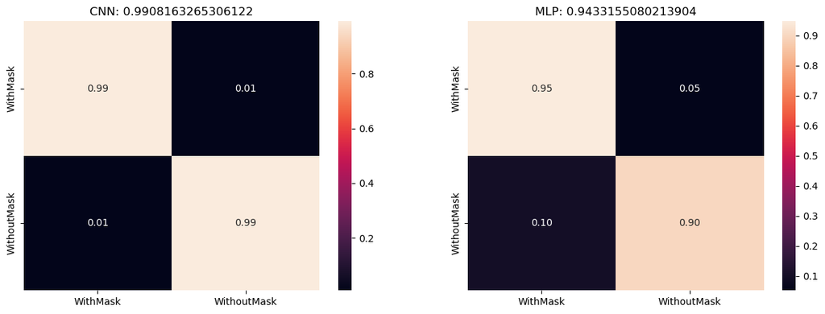

```python
compare_mlp_cnn(cnn_resnet_32, mlp, X_test, y_test, labels)
```

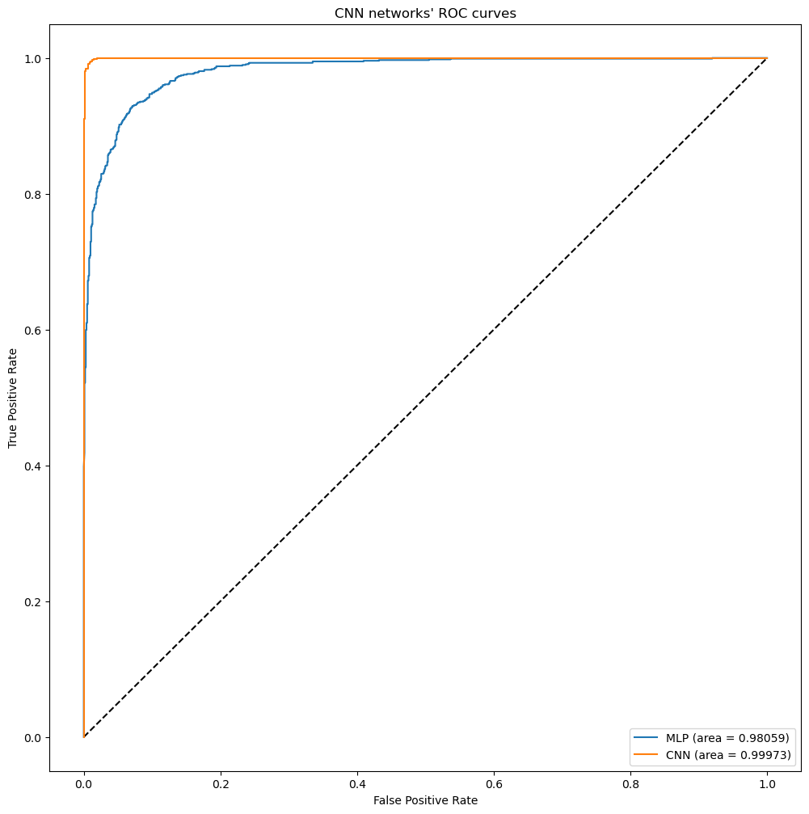

```python
from sklearn.metrics import roc_curve, roc_auc_score, average_precision_score, auc

y_pred_mlp = mlp.predict(X_test).ravel()
fpr_mlp, tpr_mlp, thresholds_mlp = roc_curve(y_test, y_pred_mlp)
precision_mlp = auc(fpr_mlp, tpr_mlp)

y_pred_cnn = cnn_resnet_32.predict(X_test).ravel()
fpr_cnn, tpr_cnn, thresholds_cnn = roc_curve(y_test, y_pred_cnn)
precision_cnn = auc(fpr_cnn, tpr_cnn)


plt.figure(figsize=(12,12))

#plot halfway line
plt.plot([0,1], [0,1], 'k--')

plt.plot(fpr_mlp, tpr_mlp, label='MLP (area = {:.5f})'.format(precision_mlp))
plt.plot(fpr_cnn, tpr_cnn, label='CNN (area = {:.5f})'.format(precision_cnn))

plt.xlabel('False Positive Rate')
plt.ylabel('True Positive Rate')
plt.title('CNN networks\' ROC curves')
plt.legend(loc='best')
plt.show()
```

```python
temp_table = create_contingency_McNemar(y_test, y_pred_mlp, y_pred_cnn)
result = mcnemar(temp_table, exact=True)

print('MLP & CNN')
print('contingency_tables:')
print(temp_table)
print('caculate the McNemar')
print(result)
if result.pvalue < 0.05:
    print('Reject the Null hypothesis: Different proportions of errors.')
else:
    print('Take the Null hypothesis: Same proportions of errors.')
print('---------------------------------------------------')
```

```
MLP & CNN
contingency_tables:
[[ 325   65]
 [ 324 1286]]
caculate the McNemar
pvalue      1.8399347200163116e-42
statistic   65.0
Reject the Null hypothesis: Different proportions of errors.
---------------------------------------------------
```

Based on the result of McNemar test, we can say that the performance between our best CNN is significantly different from MLP since they have different proportions of errors. From ROC plot above, we can see the CNN has better performance, whose area is slightly larger than MLP. Therefore, we can say that our best CNN has better performance than MLP.

# 3 Exceptional Work - Transfer Learning

We will use transfer learning with ResNet50. ResNet50 is a convolutional neural network which has 48 Convolution layer along with 1 MaxPool and 1 Average Pool layer. It has 3.8 x 10^9 Floating points operations. The pretrained network can classify images into 1000 object categories. As a result, the network has learned rich feature representations for a wide range of images.

Transfer learning with pretrained weight and networks allows us to take the learned weights from the extensive training already done and use those weights on a new classification task.

```python
from tensorflow.keras.preprocessing import image
from tensorflow.keras.applications.resnet50 import ResNet50
from tensorflow.keras.applications.resnet50 import preprocess_input, decode_predictions
```

```python
# get the image data with 3 RGB channels
X = dataset_rgb

X_rgb_train,X_rgb_test,y_rgb_train,y_rgb_test=train_test_split(X, Y, test_size=0.2, random_state=1, shuffle = True)

X_rgb_train = X_rgb_train/255.0-0.5
X_rgb_test = X_rgb_test/255.0-0.5

print(X_rgb_train.shape)
```

```
(8000, 50, 50, 3)
```

```
(8000, 50, 50, 3)
(50, 50, 3)
```

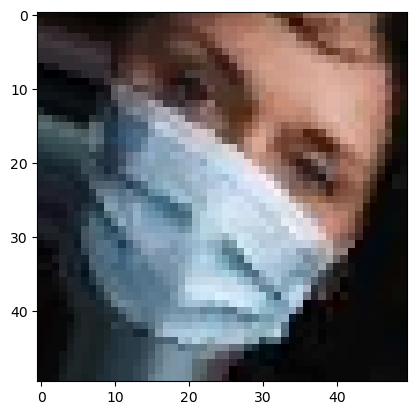

```python
print(X_rgb_train.shape)
print(X_rgb_train[1].shape)
plt.subplot(1,1,1)
plt.imshow(X_rgb_train[35]+0.5)
plt.show()
```

For the `preprocess_input` method of ResNet required a three-channel input, we used the image data with RGB values.

```python
%%time

datagen.fit(X_rgb_train)
# Add augmented data to training data set
X_new, y_new = datagen.flow(X_rgb_train, y_rgb_train, batch_size=int(len(X_rgb_train)/5)).next()
X_rgb_train = np.concatenate((X_rgb_train, X_new))
y_rgb_train = np.concatenate((y_rgb_train, y_new))

# preprocess X_train and X_test data for Res model
X_train_up = preprocess_input(X_rgb_train)
X_test_up = preprocess_input(X_rgb_test)

print(X_train_up.shape)
print(y_rgb_train.shape)
```

```
(9600, 50, 50, 3)
(9600, 1)
CPU times: user 1.39 s, sys: 443 ms, total: 1.83 s
Wall time: 1.84 s
```

```python
%%time
# load only convolutional layers of resnet:
if 'res_no_top' not in locals():
    res_no_top = ResNet50(weights='imagenet',include_top=False)

# predict convolutional layer output using existing Res weights - this takes a while
X_train_resnet = res_no_top.predict(X_train_up)
X_test_resnet = res_no_top.predict(X_test_up)
print(X_train_resnet.shape)
```

```
(9600, 2, 2, 2048)
CPU times: user 2min 56s, sys: 2min, total: 4min 57s
Wall time: 55.3 s
```

```python
%%time

# let's add a fully-connected layer
input_X = Input(shape=X_train_resnet[0].shape)
x = Flatten()(input_X)
x = Dense(256, activation='relu',kernel_initializer='he_uniform')(x)
predictions = Dense(1, activation='sigmoid')(x)

model_resnet = Model(inputs=input_X, outputs=predictions)

model_resnet.summary()
```

```
Model: "model_5"
_________________________________________________________________
 Layer (type)                Output Shape              Param #
=================================================================
 input_7 (InputLayer)        [(None, 2, 2, 2048)]      0

 flatten_10 (Flatten)        (None, 8192)              0

 dense_21 (Dense)            (None, 256)               2097408

 dense_22 (Dense)            (None, 1)                 257

=================================================================
Total params: 2,097,665
Trainable params: 2,097,665
Non-trainable params: 0
_________________________________________________________________
CPU times: user 54.5 ms, sys: 27.4 ms, total: 81.9 ms
Wall time: 44.7 ms
```

```python
%%time

model_resnet.compile(loss='binary_crossentropy',
                           optimizer='adam',
                           metrics=[keras.metrics.Precision()])

resnet_history = model_resnet.fit(X_train_resnet,y_rgb_train,epochs=200,
          batch_size=32,verbose=0,
          validation_data=(X_test_resnet, y_rgb_test),
          callbacks=[EarlyStopping(monitor='val_loss', patience=20)])
```

```
CPU times: user 11min 44s, sys: 7min 22s, total: 19min 7s
Wall time: 3min 59s
```

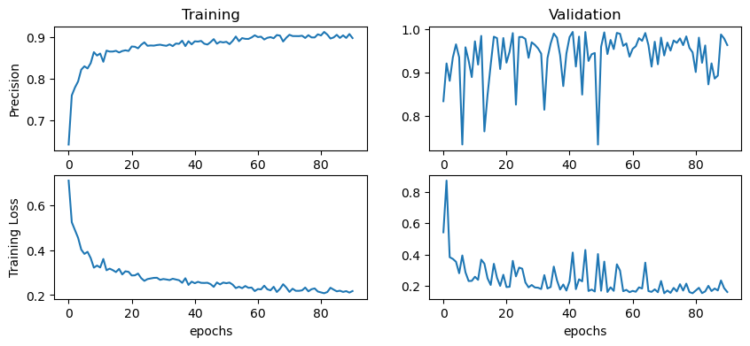

```python
plot_history(resnet_history)
```

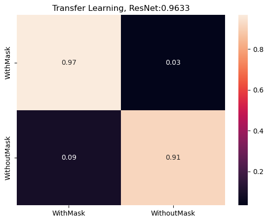

```python
show_confusion_matrix(model_resnet,X_test_resnet,y_rgb_test,labels, title_text='Transfer Learning, ResNet:')
```

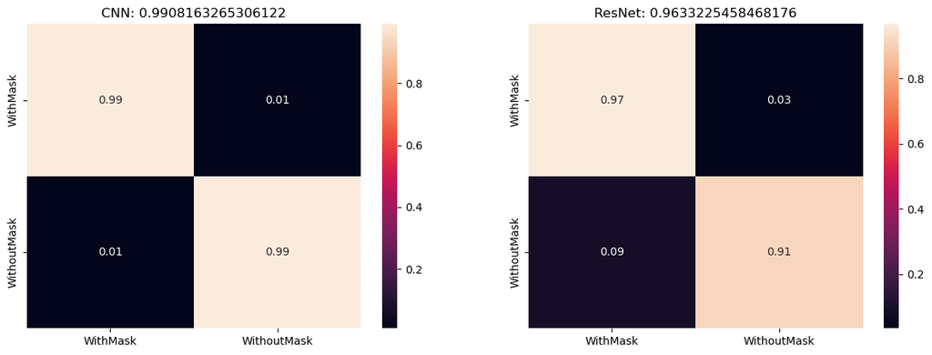

```python
def compare_res_cnn(res, cnn, X_test, y_test,X_rgb_test,y_rgb_test, labels='auto'):
    plt.figure(figsize=(15,5))
    if cnn is not None:
        yhat_cnn = np.round(cnn.predict(X_test))
        acc_cnn = mt.precision_score(y_test,yhat_cnn)
        plt.subplot(1,2,1)
        cm = mt.confusion_matrix(y_test,yhat_cnn)
        cm = cm/np.sum(cm,axis=1)[:,np.newaxis]
        sns.heatmap(cm, annot=True, fmt='.2f',xticklabels=labels,yticklabels=labels)
        plt.title('CNN: '+str(acc_cnn))

    if mlp is not None:
        yhat_mlp = np.round(res.predict(X_rgb_test))
        acc_mlp = mt.precision_score(y_rgb_test,yhat_mlp)
        plt.subplot(1,2,2)
        cm = mt.confusion_matrix(y_rgb_test,yhat_mlp)
        cm = cm/np.sum(cm,axis=1)[:,np.newaxis]
        sns.heatmap(cm,annot=True, fmt='.2f',xticklabels=labels,yticklabels=labels)
        plt.title('ResNet: '+str(acc_mlp))

compare_res_cnn(model_resnet, cnn_resnet_32, X_test, y_test,X_test_resnet,y_rgb_test, labels)
```

```python
y_pred_res = model_resnet.predict(X_test_resnet).ravel()
y_pred_cnn = cnn_resnet_32.predict(X_test).ravel()


temp_table = create_contingency_McNemar(y_test, y_pred_res, y_pred_cnn)
result = mcnemar(temp_table, exact=True)

print('ResNet & CNN')
print('contingency_tables:')
print(temp_table)
print('caculate the McNemar')
print(result)
if result.pvalue < 0.05:
    print('Reject the Null hypothesis: Different proportions of errors.')
else:
    print('Take the Null hypothesis: Same proportions of errors.')
print('---------------------------------------------------')
```

```
ResNet & CNN
contingency_tables:
[[   0    0]
 [ 649 1351]]
caculate the McNemar
pvalue      8.561755269564074e-196
statistic   0.0
Reject the Null hypothesis: Different proportions of errors.
---------------------------------------------------
```

Based on the result of McNemar test, we can say that the performance between our best CNN is significantly different from ResNet-base transfer model since they have different proportions of errors.